# hw2

caojilin

2/12/2019

#### Honor Code

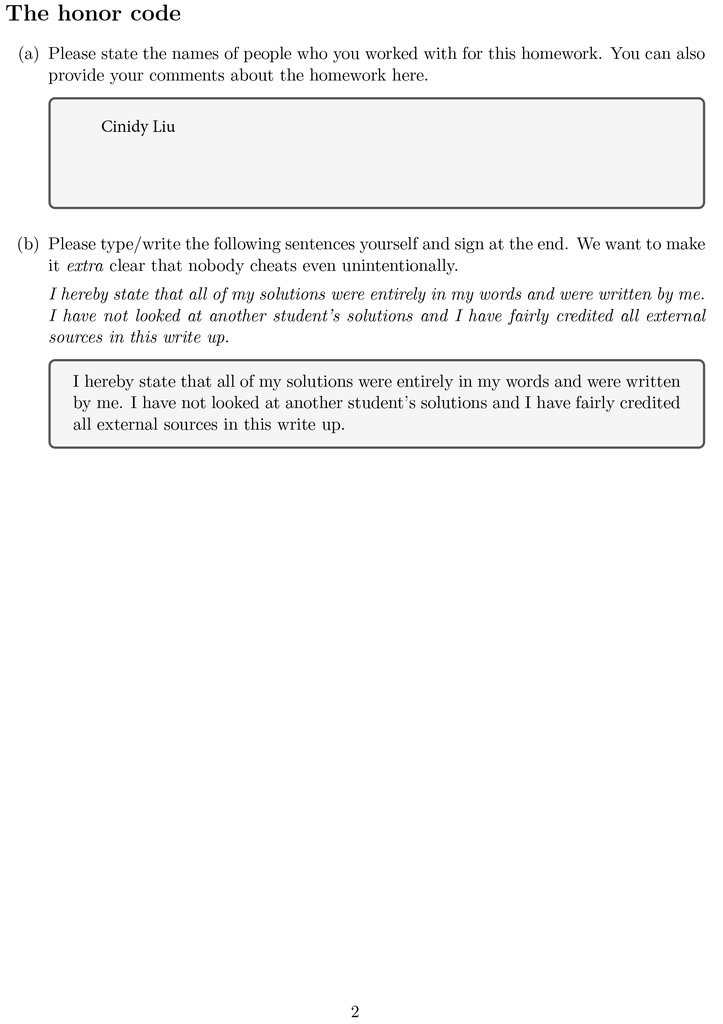

#### 1

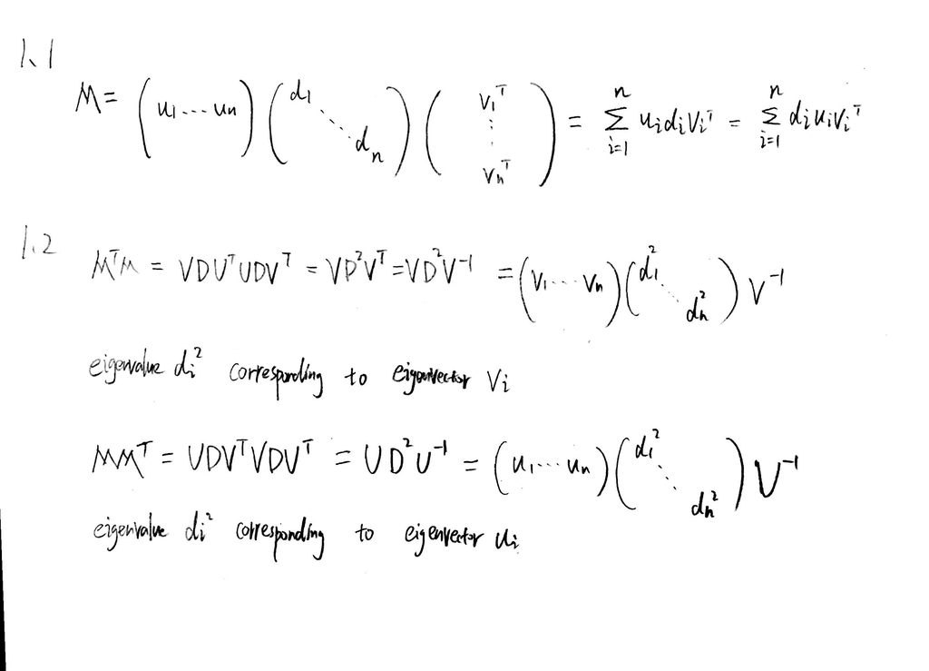

#### 1.3

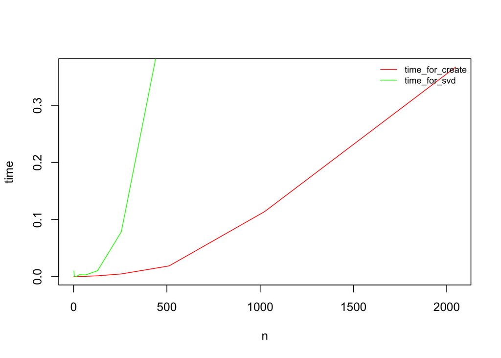

#### 2.1 First eigenvector and eigenvector

```r
#a,b,c,e
power_method = function(A, d, k){
  #Start with an arbitrary vector w0
  w = rnorm(d)
  for (i in 1:k) {
    s = max(abs(A %*% w))
    w = (A %*% w) / s
  }
  w = w/ sqrt(sum(w^2))
  return(data.frame(w, s))
}
A  = matrix(c(1,2,3,2,-1,4,3,4,-5), 3,3,byrow = TRUE)
output = power_method(A,3,10)
w = output$w
s = output$s
```

```r
#d
(t(w) %*% A %*% w) / t(w) %*% w
```

```
##           [,1]
## [1,] -7.767544
```

```r
max(abs(eigen(A)$values))
```

```
## [1] 7.768189
```

```r
#they are very close
```

```r
eigen(A)
```

```
## eigen() decomposition
## $values
## [1]  4.610843 -1.842654 -7.768189
##
## $vectors
##            [,1]       [,2]       [,3]
## [1,] -0.6890036  0.6985555 -0.1931172
## [2,] -0.5672220 -0.6856083 -0.4562899
## [3,] -0.4511466 -0.2048451  0.8686226
```

```r
#
paste(c("eigenvector by power method: ", round(w,7)), collapse=" ")
```

```
## [1] "eigenvector by power method:  -0.1980819 -0.4603714 0.8653448"
```

```r
paste(c("eigenvalue by power method: ", s[1]), collapse=" ")
```

```
## [1] "eigenvalue by power method:  7.69053696953656"
```

#### 2.2 Defation and more eigenvectors

```r
#a
B = matrix(c(5,1,0,1,4,0,0,0,1), 3, 3, byrow = TRUE)

output = power_method(B,3,20)
lambda1 = output$s
v1 = output$w
```

```r
#b
B1 = B - lambda1 * v1 %*% t(v1)
output2 = power_method(B1, 3, 20)
lambda2 = output2$s
v2 = output2$w
```

```r
#c
B2 = B1 - lambda2 * v2 %*% t(v2)
output3 = power_method(B2, 3, 20)
lambda3 = output3$s
v3 = output3$w
evalues = round(c(lambda1[1],lambda2[1],lambda3[1]),5);evalues
```

```
## [1] 5.61906 3.38197 1.00000
```

```r
evectors = matrix(round(c(v1,v2,v3),5),3,3);evectors
```

```
##         [,1]     [,2] [,3]
## [1,] 0.85042 -0.52636    0
## [2,] 0.52611  0.85026    0
## [3,] 0.00000  0.00000   -1
```

```r
eigen(B)
```

```
## eigen() decomposition
## $values
## [1] 5.618034 3.381966 1.000000
##
## $vectors
##           [,1]       [,2] [,3]
## [1,] 0.8506508  0.5257311    0
## [2,] 0.5257311 -0.8506508    0
## [3,] 0.0000000  0.0000000    1
```

```r
#They are very close to R's output
```

#### 3 Principal Component Analysis

##### (a)

```
## [1] "mean by col"
```

```
##   Murder  Assault UrbanPop     Rape
##    7.788  170.760   65.540   21.232
```

```
## [1] "variance by col"
```

```
##     Murder    Assault   UrbanPop       Rape
##   18.97047 6945.16571  209.51878   87.72916
```

##### (b)

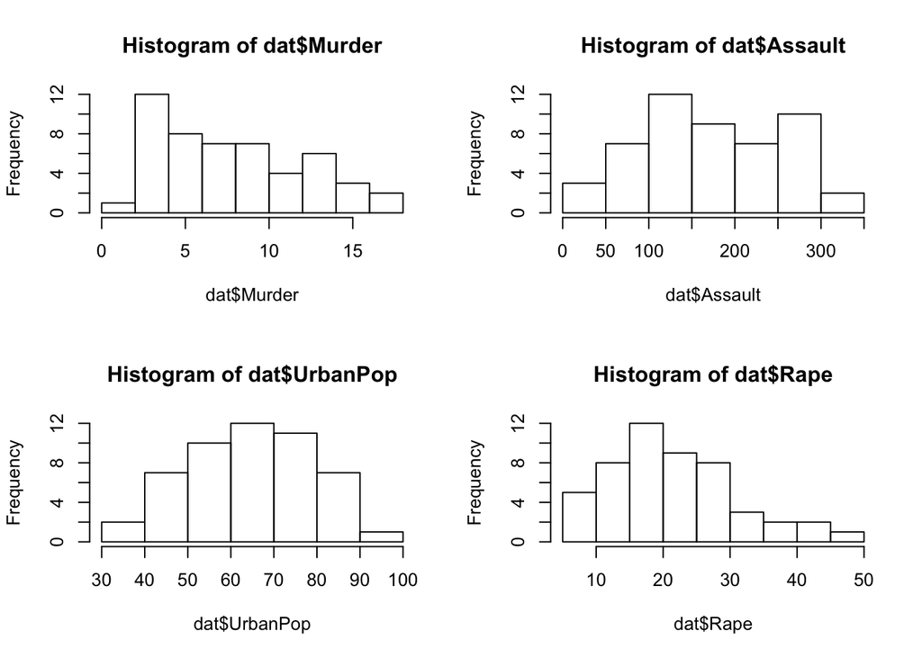

##### (c)

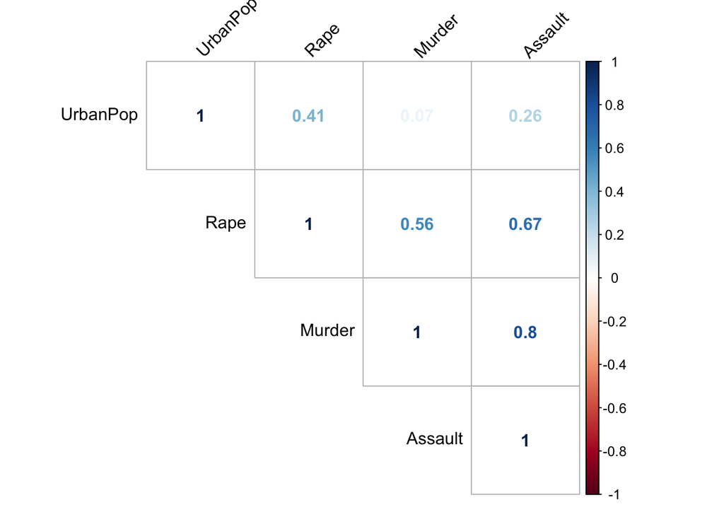

we see that crimes(Rape, Murder and Assualt) have high correlations to each other while UrbanPop does not.

##### (d)

```
## Importance of components:
##                           PC1    PC2     PC3     PC4
## Standard deviation     1.5749 0.9949 0.59713 0.41645
## Proportion of Variance 0.6201 0.2474 0.08914 0.04336
## Cumulative Proportion  0.6201 0.8675 0.95664 1.00000
```

##### (e)

```r
#(e)Obtain the principal vectors and store them in a matrix, include row and column names.
#Display the first three loadings.
pc_vectors = pca_prcomp$rotation
#first three loadings
pca_prcomp$rotation[,1:3]
```

```
##                 PC1        PC2        PC3
## Murder   -0.5358995  0.4181809 -0.3412327
## Assault  -0.5831836  0.1879856 -0.2681484
## UrbanPop -0.2781909 -0.8728062 -0.3780158
## Rape     -0.5434321 -0.1673186  0.8177779
```

##### (f)

```
##                        PC1         PC2         PC3
## Alabama        -0.97566045  1.12200121 -0.43980366
## Alaska         -1.93053788  1.06242692  2.01950027
## Arizona        -1.74544285 -0.73845954  0.05423025
## Arkansas        0.13999894  1.10854226  0.11342217
## California     -2.49861285 -1.52742672  0.59254100
## Colorado       -1.49934074 -0.97762966  1.08400162
## Connecticut     1.34499236 -1.07798362 -0.63679250
## Delaware       -0.04722981 -0.32208890 -0.71141032
## Florida        -2.98275967  0.03883425 -0.57103206
## Georgia        -1.62280742  1.26608838 -0.33901818
## Hawaii          0.90348448 -1.55467609  0.05027151
## Idaho           1.62331903  0.20885253  0.25719021
## Illinois       -1.36505197 -0.67498834 -0.67068647
## Indiana         0.50038122 -0.15003926  0.22576277
## Iowa            2.23099579 -0.10300828  0.16291036
## Kansas          0.78887206 -0.26744941  0.02529648
## Kentucky        0.74331256  0.94880748 -0.02808429
## Louisiana      -1.54909076  0.86230011 -0.77560598
## Maine           2.37274014  0.37260865 -0.06502225
## Maryland       -1.74564663  0.42335704 -0.15566968
## Massachusetts   0.48128007 -1.45967706 -0.60337172
## Michigan       -2.08725025 -0.15383500  0.38100046
## Minnesota       1.67566951 -0.62590670  0.15153200
## Mississippi    -0.98647919  2.36973712 -0.73336290
## Missouri       -0.68978426 -0.26070794  0.37365033
## Montana         1.17353751  0.53147851  0.24440796
## Nebraska        1.25291625 -0.19200440  0.17380930
## Nevada         -2.84550542 -0.76780502  1.15168793
## New Hampshire   2.35995585 -0.01790055  0.03648498
## New Jersey     -0.17974128 -1.43493745 -0.75677041
## New Mexico     -1.96012351  0.14141308  0.18184598
## New York       -1.66566662 -0.81491072 -0.63661186
## North Carolina -1.11208808  2.20561081 -0.85489245
## North Dakota    2.96215223  0.59309738  0.29824930
## Ohio            0.22369436 -0.73477837 -0.03082616
## Oklahoma        0.30864928 -0.28496113 -0.01515592
## Oregon         -0.05852787 -0.53596999  0.93038718
## Pennsylvania    0.87948680 -0.56536050 -0.39660218
## Rhode Island    0.85509072 -1.47698328 -1.35617705
## South Carolina -1.30744986  1.91397297 -0.29751723
## South Dakota    1.96779669  0.81506822  0.38538073
## Tennessee      -0.98969377  0.85160534  0.18619262
## Texas          -1.34151838 -0.40833518 -0.48712332
## Utah            0.54503180 -1.45671524  0.29077592
## Vermont         2.77325613  1.38819435  0.83280797
## Virginia        0.09536670  0.19772785  0.01159482
## Washington      0.21472339 -0.96037394  0.61859067
## West Virginia   2.08739306  1.41052627  0.10372163
## Wisconsin       2.05881199 -0.60512507 -0.13746933
## Wyoming         0.62310061  0.31778662 -0.23824049
```

##### (g)

```
## [1] 2.4802416 0.9897652 0.3565632 0.1734301
```

```
## [1] 4
```

##### (h)

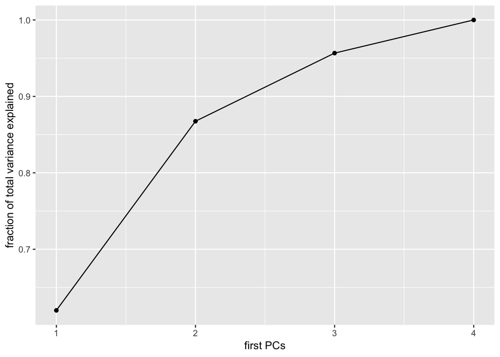

##### (i)

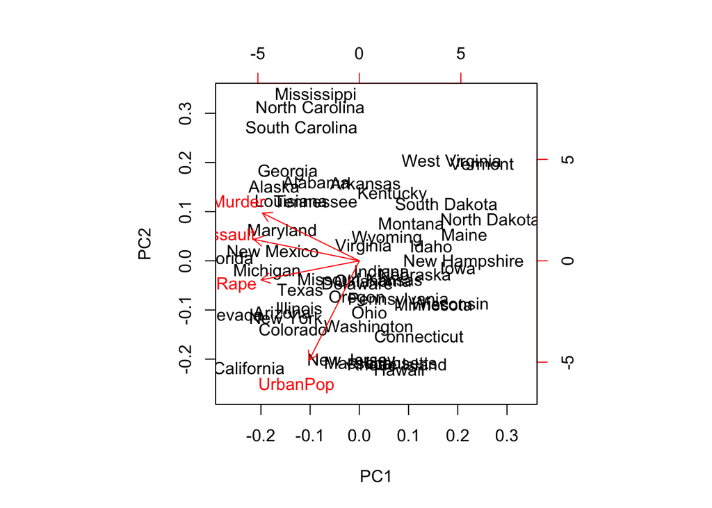

##### (j)

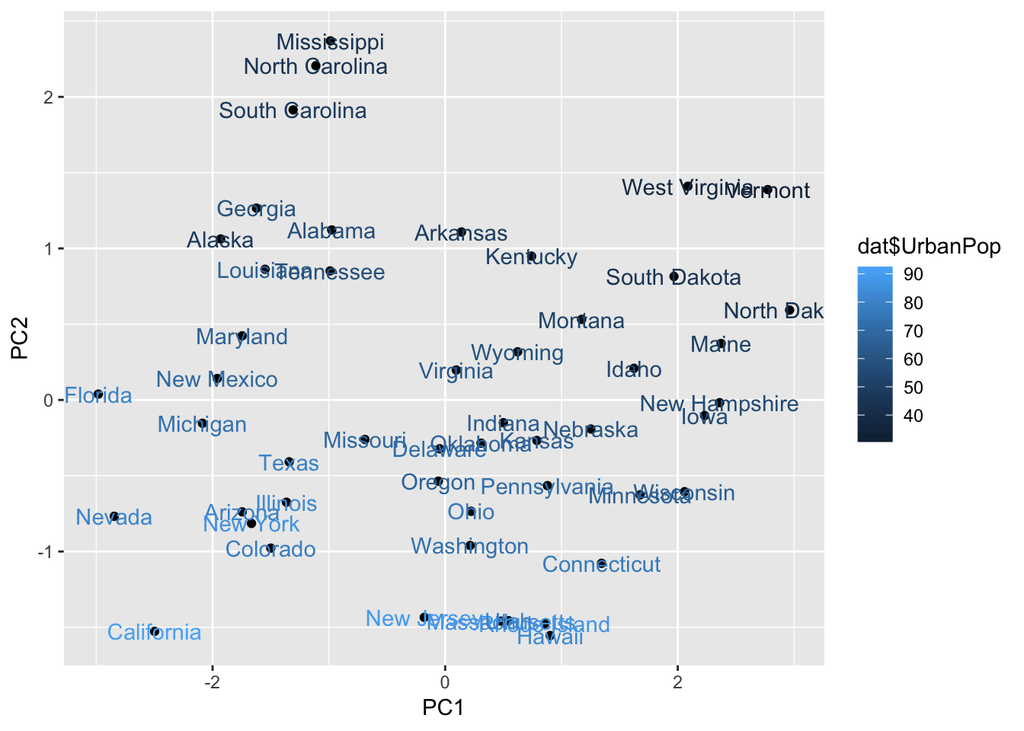

##### (k)

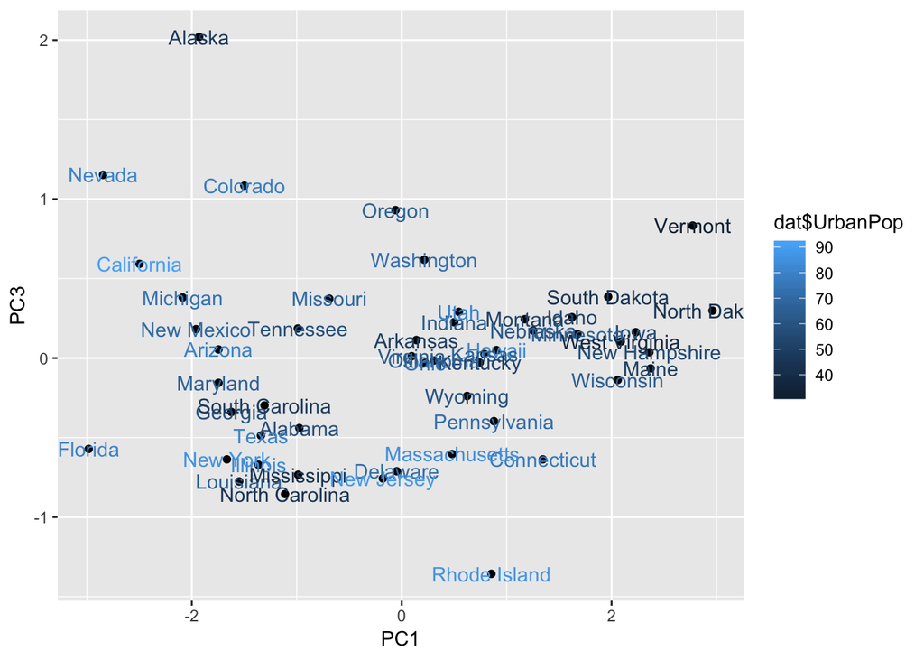

PC1 put equal weights on crimes and less weight on UrbanPop, so it measures overall crime rates  
PC3 has more weight on Rape, so it measures the Rape rates.  
So this plot displays relationship between overrall crimes and Rape.  
Nevada, Alaska and Colorado stand out for high Rape rates.  
Rhode Island has high UrbanPop but low Rape rates and crime rates.

#### 4 K-means and PCA

1. This problem involves the K-means clustering algorithm.
1. Prove (10.12).

$$\frac{1}{|C_k|} \sum\limits_{i,i^{\prime} \in C_k} \sum\limits_{j=1}^p (x_{ij} - x_{i^\prime j})^2 =
2 \sum\limits_{i \in C_k} \sum\limits_{j=1}^{p} (x_{ij} - \bar{x}_{kj})^2
\\
= \frac{1}{|C_k|} \sum\limits_{i,i^{\prime} \in C_k} \sum\limits_{j=1}^p ((x_{ij} - \bar{x}_{kj}) - (x_{i^\prime j} - \bar{x}_{kj}))^2
\\
= \frac{1}{|C_k|} \sum\limits_{i,i^{\prime} \in C_k} \sum\limits_{j=1}^p ((x_{ij} - \bar{x}_{kj})^2 - 2 (x_{ij} - \bar{x}_{kj})(x_{i^\prime j} - \bar{x}_{kj}) + (x_{i^\prime j} - \bar{x}_{kj})^2)
\\
= \frac{|C_k|}{|C_k|} \sum\limits_{i \in C_k} \sum\limits_{j=1}^p (x_{ij} - \bar{x}_{kj})^2 +
\frac{|C_k|}{|C_k|} \sum\limits_{i^{\prime} \in C_k} \sum\limits_{j=1}^p (x_{i^\prime j} - \bar{x}_{kj})^2 -
\frac{2}{|C_k|} \sum\limits_{i,i^{\prime} \in C_k} \sum\limits_{j=1}^p (x_{ij} - \bar{x}_{kj})(x_{i^\prime j} - \bar{x}_{kj})
\\
= 2 \sum\limits_{i \in C_k} \sum\limits_{j=1}^p (x_{ij} - \bar{x}_{kj})^2 + 0$$

2. On the basis of this identity, argue that the K-means clustering algorithm (Algorithm 10.1) decreases the objective (10.11) at each iteration.

above equation shows that K-means clustering algorithm equivalently decreases the within-cluster variation.  
since we recompute the centroid using squared Euclidean distance  
Step 2(b) will minimize the within-cluster sum of squares.  
Therefore it will decreases the objective each iteration.

10. In this problem, you will generate simulated data, and then perform PCA and K-means clustering on the data.

##### (a)

Generate a simulated data set with 20 observations in each of  
three classes (i.e. 60 observations total), and 50 variables.

##### (b)

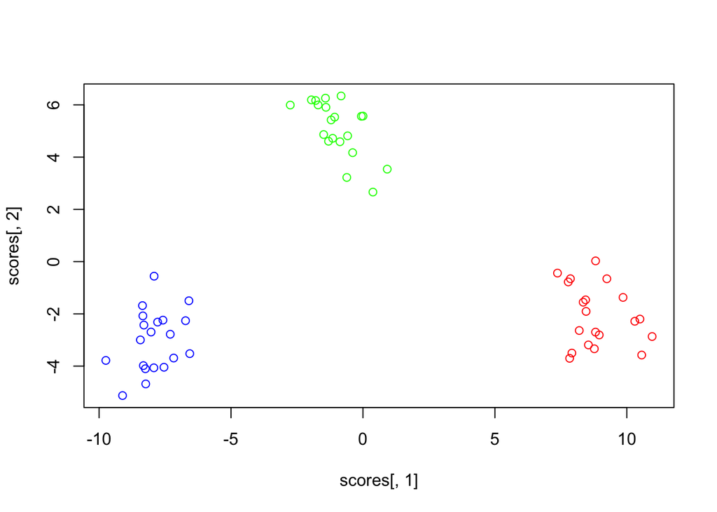

##### (c)

```
##  [1] 1 1 1 1 1 1 1 1 1 1 1 1 1 1 1 1 1 1 1 1 3 3 3 3 3 3 3 3 3 3 3 3 3 3 3
## [36] 3 3 3 3 3 2 2 2 2 2 2 2 2 2 2 2 2 2 2 2 2 2 2 2 2
```

```
##
##      1  2  3
##   1 20  0  0
##   2  0  0 20
##   3  0 20  0
```

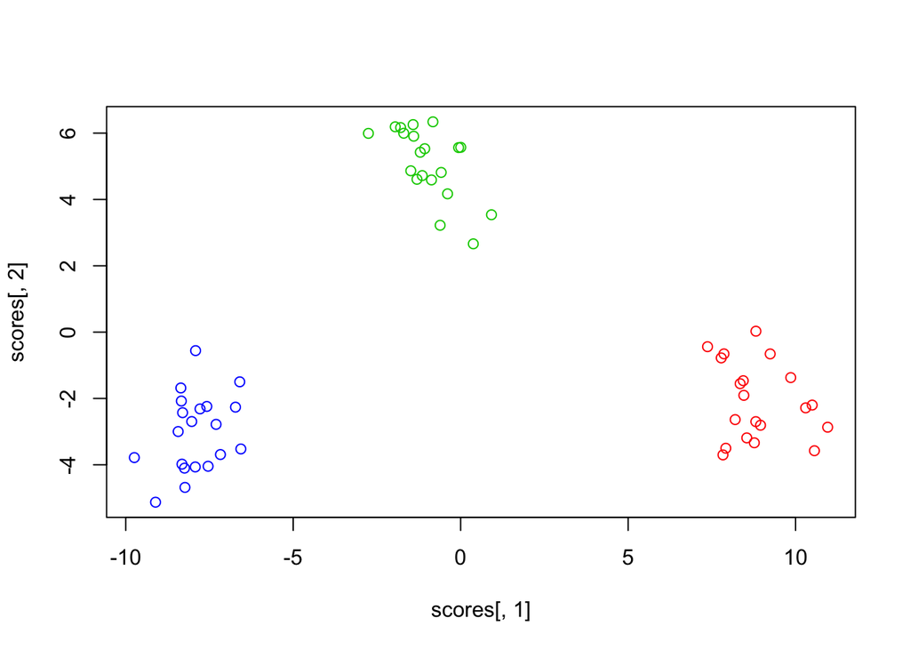

When $K = 3$, we see that the k-mean successfully classify the data

##### (d)

```
##  [1] 1 1 1 1 1 1 1 1 1 1 1 1 1 1 1 1 1 1 1 1 2 2 2 2 2 2 2 2 2 2 2 2 2 2 2
## [36] 2 2 2 2 2 2 2 2 2 2 2 2 2 2 2 2 2 2 2 2 2 2 2 2 2
```

```
##
##      1  2  3
##   1 20  0  0
##   2  0 20 20
```

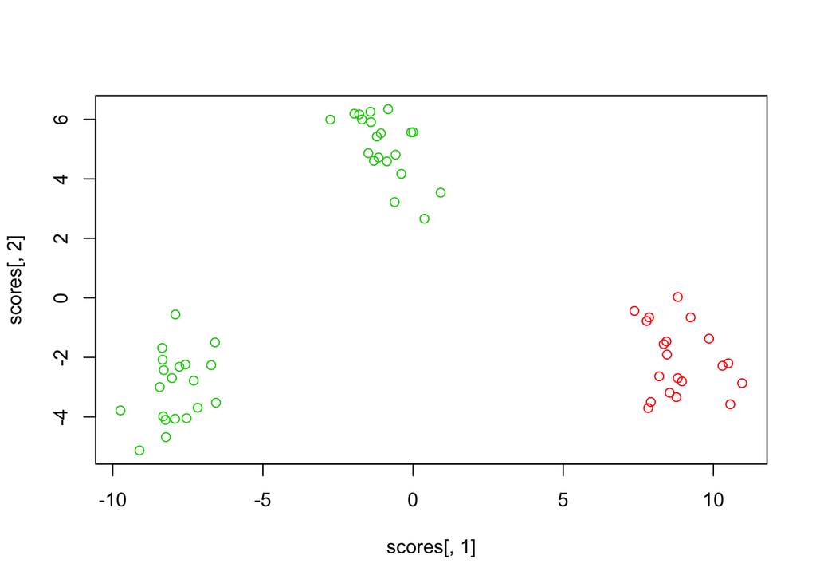

##### (e)

```
##  [1] 4 4 4 4 4 2 4 2 4 4 2 2 2 2 4 2 4 2 2 4 3 3 3 3 3 3 3 3 3 3 3 3 3 3 3
## [36] 3 3 3 3 3 1 1 1 1 1 1 1 1 1 1 1 1 1 1 1 1 1 1 1 1
```

```
##
##     TRUE1 TRUE2 TRUE3
##   1     0     0    20
##   2     9     0     0
##   3     0    20     0
##   4    11     0     0
```

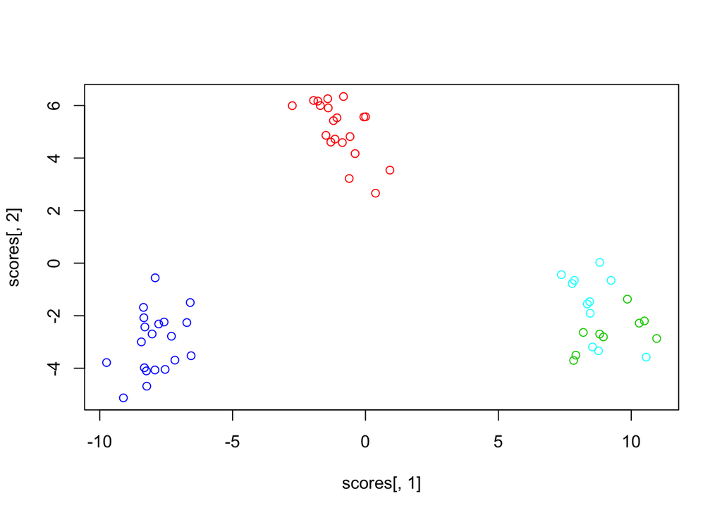

##### (f)

perform K-means clustering with K = 3 on the first two  
principal component score vectors

```
##  [1] 2 2 2 2 2 2 2 2 2 2 2 2 2 2 2 2 2 2 2 2 3 3 3 3 3 3 3 3 3 3 3 3 3 3 3
## [36] 3 3 3 3 3 1 1 1 1 1 1 1 1 1 1 1 1 1 1 1 1 1 1 1 1
```

```
##
##     TRUE1 TRUE2 TRUE3
##   1     0     0    20
##   2    20     0     0
##   3     0    20     0
```

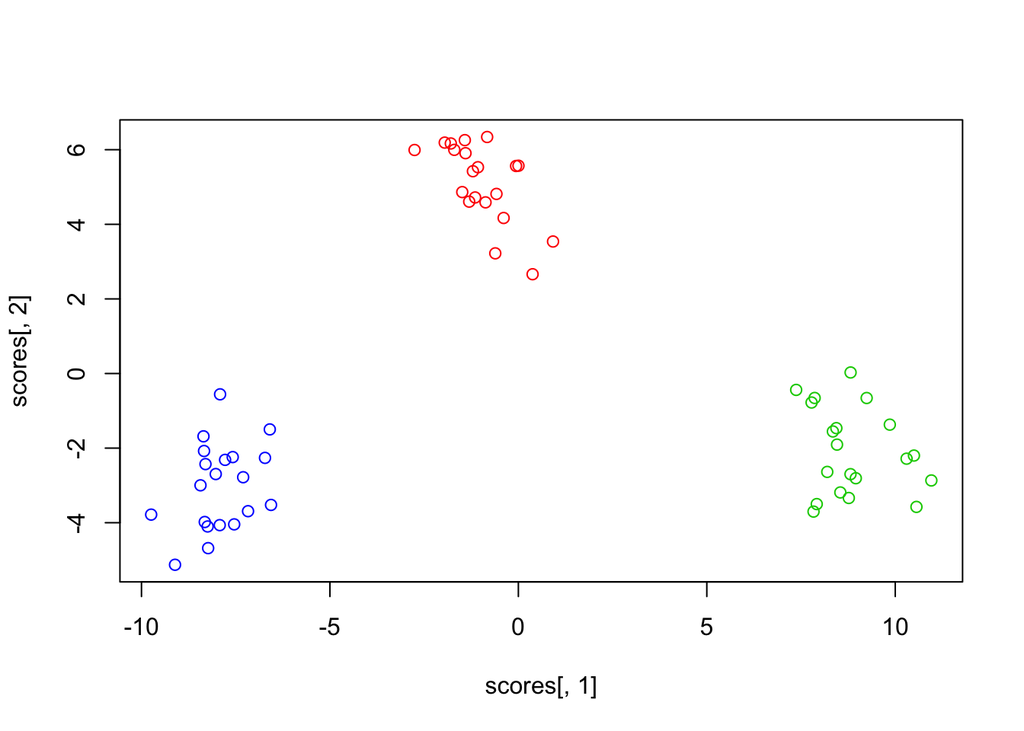

##### (g)

```
##  [1] 1 1 1 1 1 1 1 1 1 1 1 1 1 1 1 1 1 1 1 1 3 3 3 3 3 3 3 3 3 3 3 3 3 3 3
## [36] 3 3 3 3 3 2 2 2 2 2 2 2 2 2 2 2 2 2 2 2 2 2 2 2 2
```

```
##
##     TRUE1 TRUE2 TRUE3
##   1    20     0     0
##   2     0     0    20
##   3     0    20     0
```

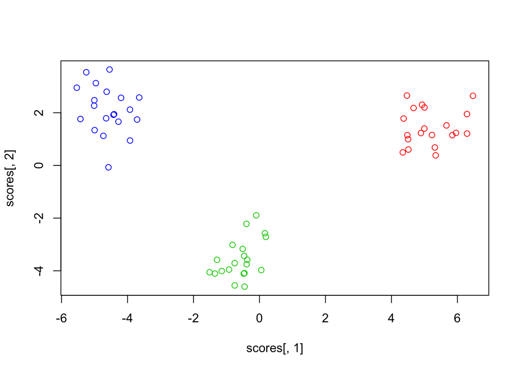

After scaling, it still gives the same result as in part b

#### 5 True or false

Examine whether the following statements are true or false and provide one line justification

**Eigenvalues obtained from the principal component analysis is always nonnegative.**  
True, $X^TX$ is a symmetric and PSD matrix, thus it has positive eigenvalues

**The first principal vector and the second principal vector are always orthogonal.**  
True, actually all principal vectors are othrogonal to each other

**Singular values of a square matrix $M$ are the same as the eigenvalues of $M$.**  
False, when the matrix M is a symmetric positive definite matrix.

**Principal components analysis can be used to create a low dimensional projection of the data.**  
True, use principal vectors as new coordinates

**Eigenvalue of a matrix are always nonnegative.**  
False, Not always. Eigenvalues can be negative.

**The maximum number of principal components is always less or equal to the feature dimension.**  
True, When n > p, maximum number of principal components are equal to p, when n < p, maximum number of principal components are equal to n.